# はじめに

MMRのご利用ありがとうございます！  
※画面が縦に潰れているときは、ブラウザ（Chrome等）のウィンドウの大きさを変えると戻ります。

## MMRとは？

Macromillで開発を行っている、R言語の様々なパッケージを簡単に使えるようにツール化したものです。  
Rのコードを書かずに、Rをインストールしていなくても、Rの便利で強力なデータ集計・分析機能を利用することができます。

## MMRでできること

データ前処理：データを結合・フィルタリングして集計解析しやすくすることができます。  
集計・可視化：データを集計して、ピボットテーブルやグラフで視覚化することができます。  
データ解析：データを様々な統計解析にかけることができます。  
テキスト解析：テキストを単語に分解したり、ランキングやワードクラウド、共起ネットワークを作成できます。

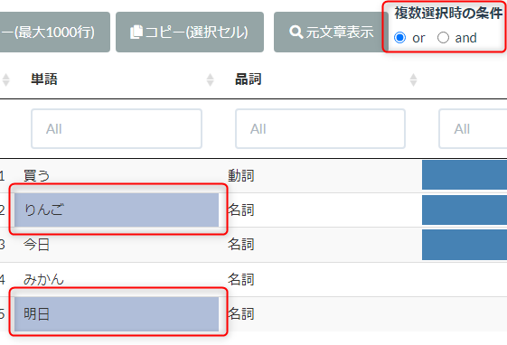

# 連絡先

不具合・修正のご要望などはメール・Teamsまでお寄せいただけますと幸いです。

開発担当者にメールを送る：池田拓郎・林潔・坂口雅哉

マクロミル内のTeamsに投稿：MMR不具合・修正・要望チャンネル

## 新規ユーザーの登録申請

新規ユーザーの申請はこちらのTeamsチャネルまで